# ROSMAP snRNA-seq: Feature Selection to Clustering

Won-Min Song

November 18, 2021

## Run-down for snRNA-seq clustering analysis for ROSMAP data

This code includes The .RDS file for the pre-processed seurat object can be found at: https://www.synapse.org/#!Synapse:syn26477245. You need to put this file under "Output" directory for the tutorial code to run. Other outputs from clustering results will be stored under "clustering_results". You may choose to change this for the desired output folder otherwise. Please note that, while this tutorial uses gene variance calculation routine from Seurat (based on variance stabilizing transformation), we also provide dispersion calculations in Scran. The user may choose to do either scran or seurat routine by turning use.scran/use.seurat = TRUE/FALSE per section.

```r
##  Load necessary packages and functions into R
rm(list = ls())
library(Seurat)
```

```r
library(ggplot2)
library(ggrepel)
library(scran)
print(getwd())
```

```
## [1] "C:/Users/songw01/Documents/Papers/AD_scRNAseq_Review/example_codes/AD_scRNAseq_companion"
```

```r
out.dir <- "clustering_results";dir.create(out.dir)
source("./scripts/R_functions/enrichment_functions.v2.R")
source("./scripts/R_functions/clustering_functions.v1.R")
```

## data loading

```r
seu = readRDS("Output/SeuratObject.RDS")
#urlstr <- "https://www.dropbox.com/s/w0mzab5i3dwxwlp/SeuratObject.RDS?raw=1"
#seu = readRDS(url(urlstr))
print(seu)
```

```
## An object of class Seurat
## 35350 features across 70634 samples within 2 assays
## Active assay: SCT (17575 features, 3000 variable features)
##  1 other assay present: RNA
##  3 dimensional reductions calculated: pca, umap, tsne
```

# use modelGeneVar function from scran

Here, we will demonstrate how to select genes with significant dispersions by using modelGeneVar() from scran workflow, or FindVariableFeatures() from Seurat

```
## When using repel, set xnudge and ynudge to 0 for optimal results
```

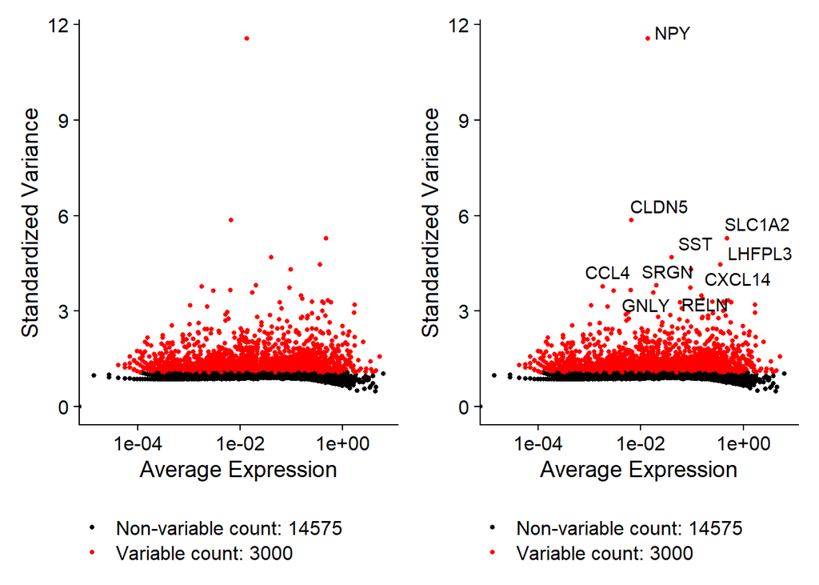

```r
use.scran = FALSE # use scran workflow
use.seurat = TRUE # use seurat workflow

if (use.scran)
{
    gene.var = modelGeneVar(x = GetAssayData(seu),block = factor(seu@meta.data$individualID))
    gene.var =gene.var[order(gene.var$bio,decreasing = TRUE),]

    # get significant genes
    gene.sig.var = subset(gene.var,FDR < 0.05) # significant dispersion genes with FDR < 0.05

    # populate variable genes in seurat
    seu[["SCT"]]@var.features = rownames(gene.sig.var)

    library(ggplot2)
    library(ggrepel)
    pobj = ggplot() + geom_point(data = as.data.frame(gene.var[,1:6]),aes(x = tech,y = bio,colour = FDR < 0.05),alpha = 0.2) +
      scale_colour_manual(values = c("TRUE" = "red","FALSE" = "gray")) +
      geom_text_repel(data = subset(data.frame(gene.var[1:20,1:6],gene = rownames(gene.var)[1:20]),FDR < 0.05),aes(x = tech,y = bio,label = gene),size = 5) + # name top 20 genes for viz.
      labs(x = "Technical",y = "Biological") +
      guides(colour = guide_legend(title = "Biological Var.\nFDR < 0.05")) +
      theme_bw() +
      theme(axis.title = element_text(size = 20),axis.text = element_text(size = 17),
        legend.position = "bottom",legend.title = element_text(size = 20),
        legend.text = element_text(size = 17),legend.direction = "horizontal")

    png(file = paste0(out.dir,"/scran_variance.png"),res = 300,width = 1800,height = 2100)
    print(pobj)
    dev.off()

    pobj
}

if (use.seurat)
{
    # Seurat's VST routine: note that nfeatures = 3000 is set. While Seurat recommends 2000, 3000 may be more liberal to include more variability in the data set.
    seu = FindVariableFeatures(
      object= seu,
      selection.method = "vst",
      nfeatures = 3000,
      verbose = TRUE
    )
    # plot variable features with and without labels
    top10 <- head(VariableFeatures(seu), 10)
    plot1 <- VariableFeaturePlot(seu) + theme(legend.position = "bottom",legend.direction = "vertical")
    plot2 <- LabelPoints(plot = plot1, points = top10, repel = TRUE) + theme(legend.position = "bottom",legend.direction = "vertical")
    png(file = paste0(out.dir,"/Seurat_variable_features.png"),res = 300,width = 3200,height = 2500)
    plot1 + plot2
    dev.off()

    plot1 + plot2
}
```

```r
print(length(seu[["SCT"]]@var.features))
```

```
## [1] 3000
```

## PCA data

Now, let's perform PCA. This portion includes two pipelines for PC selection: getDenoisedPCs from scran, and observing explained variance curve for Seurat.

```r
use.scran = FALSE # use scran workflow
use.seurat = TRUE # use seurat workflow

### scran workflow to nominate PCs
if (use.scran)
{
    ## get SCT normalized data from Seurat: But, this matrix can be any log-normalized data for scRNA-seq
    mat = GetAssayData(seu);
    mat = mat[match(rownames(gene.sig.var),rownames(mat)),]

    # in case you would want to denoise PCs
    pcs.denoised <- getDenoisedPCs(mat, technical=gene.sig.var)

    # replace PCA components in Seurat object
    seu$pca@cell.embeddings = pcs.denoised$components[colnames(seu),]

    # run UMAP on updated PCs
    seu <- RunUMAP(seu, dims = 1:ncol(pcs.denoised$components), seed.use = 4867)
}


### seurat workflow to nominate PCs
if (use.seurat)
{
    # Run PCA in seurat workflow
    seu <- ScaleData(seu, features = rownames(seu))
    seu = RunPCA(seu, features = VariableFeatures(object = seu))

    # Get the total variance:
    total_variance <- sum(matrixStats::rowVars(Seurat::GetAssayData(seu, assay = "SCT", slot = "scale.data")))
    eigValues =  (seu$pca@stdev)^2

    pca.pdata = data.frame(PC = 1:length(seu$pca@stdev),
    eigValues = (seu$pca@stdev)^2,  ## EigenValues
    varExplained = eigValues / total_variance * 100,
    totalExplained = cumsum(eigValues / total_variance * 100))

    pobj = ggplot(data = pca.pdata,aes(x = PC,y = varExplained)) + geom_point() + geom_line() +
    geom_vline(xintercept = c(5,7,20),colour = c("red","blue","green")) +
    theme_bw() +
    labs(x = "PCs",y = "%. Variance Explained") +
    theme(axis.title = element_text(size = 20),axis.text = element_text(size = 17))

    png(file = paste0(out.dir,"/variance_explained.png"),res = 300,width = 2400,height = 2100)
    print(pobj)
    dev.off()

    pobj

    n.pcs = 20 # use 20 PCs after inspecting the plot
    seu <- RunUMAP(seu, dims = 1:n.pcs, seed.use = 4867)

}
```

```
## PC_ 1
## Positive:  RBFOX1, CSMD1, KCNIP4, RALYL, LRRTM4, TENM2, SNTG1, IQCJ-SCHIP1, DPP10, GPM6A
##     ASIC2, CNTNAP2, LINGO2, CDH18, DGKB, ROBO2, UNC5D, HS6ST3, KCTD16, ST6GALNAC5
##     CDH12, DSCAM, PCDH7, CNTN4, RGS6, FAM19A2, SYN3, NRGN, GRIN1, ENC1
## Negative:  PLP1, QKI, MBP, ST18, CTNNA3, RNF220, PIP4K2A, SLC44A1, CLDN11, TMEM144
##     PHLPP1, PDE4B, NCKAP5, TMTC2, DOCK10, DOCK5, CNP, FRMD4B, TF, PTGDS
##     ZBTB20, C10orf90, ERBB2IP, GPM6B, EDIL3, CREB5, ENPP2, TMEM165, ELMO1, MAN2A1
## PC_ 2
## Positive:  IL1RAPL1, SLC24A2, PLP1, PEX5L, ST18, TTLL7, CTNNA3, MBP, CLDN11, CNTNAP2
##     SLC44A1, APLP1, FRMD5, RNF220, DPYD, PRUNE2, PLCL1, SH3GL3, MAP7, ELMO1
##     TMEM144, SHTN1, EDIL3, IQCJ-SCHIP1, MOBP, QDPR, ENPP2, TMEFF2, PDE1C, KIRREL3
## Negative:  SLC1A2, ATP1A2, HIF3A, ADGRV1, CST3, PITPNC1, PARD3, SLC1A3, NKAIN3, GJA1
##     AQP4, GPC5, RANBP3L, COL5A3, APOE, PTPRZ1, FGFR3, RFX4, NHSL1, TPD52L1
##     SLC14A1, RYR3, PLPP3, MSI2, BMPR1B, ZNF98, DTNA, HPSE2, CABLES1, PREX2
## PC_ 3
## Positive:  NXPH1, LHFPL3, PCDH15, LUZP2, VCAN, GRIK1, MEGF11, SMOC1, KAZN, TNR
##     GAD1, SGCZ, MYO16, ALK, SOX6, TMEM132C, ADARB2, SEMA5A, ZNF385D, KCNIP1
##     LRRC4C, COL9A1, FERMT1, XKR4, KIF26B, GPNMB, DAB1, STK32A, XYLT1, ERBB4
## Negative:  ADGRV1, GJA1, AQP4, RANBP3L, SLC14A1, BMPR1B, COL5A3, CLU, FGFR3, GPC5
##     ETNPPL, TPD52L1, PRDM16, SLC39A12, ACSBG1, LRRC16A, APOE, PAPLN, GFAP, SLC7A11
##     GLIS3, RYR3, SLCO1C1, ZNF98, ZNRF3, MLC1, SLC1A3, STON2, EMX2, SDC4
## PC_ 4
## Positive:  NTM, GPM6A, LRP1B, CTNNA2, PPP2R2B, RORA, NCAM2, NPAS3, NEBL, LRRTM4
##     CACNB2, CSMD1, LRRC4C, ERBB4, CNTNAP2, TENM2, SPARCL1, SORBS1, SLC1A2, RBFOX1
##     IL1RAPL1, DPP10, PCDH7, SGCD, SNTG1, GPC5, GRIA4, GPM6B, HS6ST3, SOX5
## Negative:  DOCK8, APBB1IP, TBXAS1, FYB, CD74, INPP5D, SYK, C3, SLCO2B1, C10orf11
##     ADAM28, ST6GAL1, CSF1R, RHBDF2, ARHGAP15, PTPRC, FLI1, ARHGAP24, LY86, BLNK
##     PALD1, SRGAP2, LYN, P2RY12, IKZF1, RBM47, CSF3R, RUNX1, CSF2RA, LPCAT2
## PC_ 5
## Positive:  VCAN, CA10, TNR, DSCAM, KCNIP4, PDZD2, MEGF11, SMOC1, GPNMB, LHFPL3
##     XYLT1, FERMT1, STK32A, PTPRZ1, COL9A1, SEMA5A, ZFPM2, BRINP3, COL20A1, FAM19A1
##     KIF13A, DGKG, PDGFRA, MMP16, PDZRN4, CSPG4, SEZ6L, EPN2, CRISPLD2, GPR17
## Negative:  GAD2, ZNF385D, GAD1, GRIP1, BTBD11, ANK1, ERBB4, GRIP2, RBMS3, PTPRM
##     KCNC2, TAC1, SLC35F4, LHX6, SLC6A1, NHS, KCNAB1, PTCHD4, ZNF536, VWC2
##     TENM3, IGF1, CNTNAP3B, MYO16, MAFB, PVALB, RGS5, SNRPN, TRPC4, ARL4C
```

## UMAP Embedding

```r
# jointly visualize with other complex features
xy = Embeddings(seu,"umap")
pdata = cbind.data.frame(seu@meta.data,as.data.frame(xy[match(colnames(seu),rownames(xy)),]))
pdata$pathology.group = gsub("late","Late AD",gsub("early","Early AD",gsub("no","Healthy",gsub("-pathology$","",as.character(pdata$pathology)))))

# get cluster label coordinate
xy.o = do.call('rbind',lapply(split(1:nrow(xy),factor(seu@meta.data$seurat_clusters)),function(x,y) apply(rbind(y[x,]),2,function(q) median(q)),y = xy));colnames(xy.o) = c("x","y")
hobj = hclust(dist(xy.o),"complete")
cls.tick = hobj$label[hobj$order]

# first create comprehensive uMAP plot
colmap = c("Healthy" = "darkolivegreen1","Early AD" = "yellow","Late AD" = "coral")

pobj = ggplot() +
  geom_point(data = pdata,aes(x = UMAP_1,y = UMAP_2,fill = pathology.group,colour = broad.cell.type),shape = 21,alpha = 0.4,size = 3,stroke = 1.5) +
  geom_text(data = data.frame(cls.id = rownames(xy.o),as.data.frame(xy.o)),aes(x = x,y = y,label = cls.id),size = 7) +
  scale_fill_manual(values = colmap) +
  guides(fill = guide_legend(title = "Diagnosis",ncol = 3),colour = guide_legend(title = "Cell Type",ncol = 3)) +
  theme_bw() +
  theme(axis.ticks = element_blank(),axis.title = element_blank(),axis.text = element_blank(),
        panel.grid.major = element_blank(), panel.grid.minor = element_blank(),
        panel.background = element_blank(),
        legend.title = element_text(size = 20),legend.text = element_text(size = 18),
        legend.position = "bottom",legend.direction = "horizontal")

png(file = paste0(out.dir,"/umap.png"),res = 300,width = 3500,height = 2800)
print(pobj)
dev.off()
```

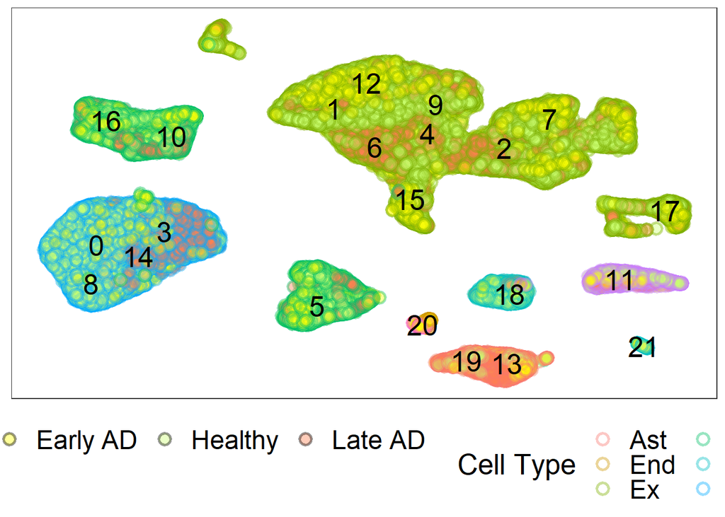

```r
pobj
```

## Marker plotting on UMAP

```r
# get marker expression plots
genes = c("Ex" = "NRGN","In" = "GAD1","Ast" = "AQP4","Ast" = "GFAP",
          "Mic" = "TYROBP","Mic" = "CX3CR1","Oli" = "PLP1","OPC" = "VCAN","End" = "FLT1")
dobj = DotPlot(seu, features = genes) + RotatedAxis() + scale_y_discrete(limits = cls.tick) +
  labs(x = "Cell type marker",y = "Cluster") +
  theme(axis.text.y = element_text(size = 16),axis.text.x = element_text(size = 14),
        legend.position = "bottom",legend.direction = "vertical")

png(file = paste0(out.dir,"/Celltype_Markers.Dotplot.png"),res = 300,width = 1700,height = 2700)
print(dobj)
dev.off()
```

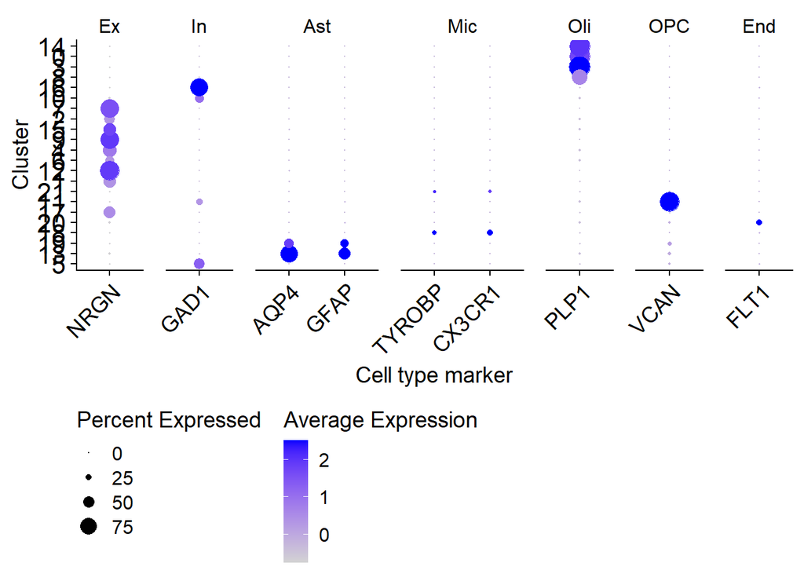

```r
dobj
```

## Composition analysis

```r
## create proportion plot
# assign features
mods = split(colnames(seu),Idents(seu));
vec = seu@meta.data$pathology.group;names(vec) = colnames(seu);
vec[vec == "early-pathology"] = "Early AD"
vec[vec == "late-pathology"] = "Late AD"
vec[vec == "no-pathology"] = "Healthy"


colmap = c("Healthy" = "darkolivegreen1","Early AD" = "yellow","Late AD" = "coral")

# check enrichments
fet.res = perform.AllPairs.FET(geneSets1 = mods,geneSets2 = split(names(vec),factor(vec)),background = colnames(seu),adjust.FET.pvalue = T,or = 1,alternative = "greater",
                               do.multicore = F,n.cores = NULL)
fet.res = fet.res[order(fet.res$FET_pvalue),]
fet.res$corrected.FET.pvalue = p.adjust(fet.res$FET_pvalue,"BH")

require(reshape2)
pmat = acast(data = fet.res,formula = set1_Name ~ set2_Name,value.var = "corrected.FET.pvalue")

# get coordinates for marks
m = overlap_modules_wt_categ(mods,vec);
m = m[,match(rev(names(colmap)),colnames(m))]
dot.coord = t(apply(m,1,function(x) cumsum(x) - 0.5*x))

# make data for dot marks
dot.data = subset(fet.res,corrected.FET.pvalue < 0.05 & enrichment.foldchange > 1.2)
ij = cbind(match(as.character(dot.data$set1_Name),rownames(dot.coord)),match(as.character(dot.data$set2_Name),colnames(dot.coord)))
dot.data$y = apply(ij,1,function(x,m) m[x[1],x[2]],m = dot.coord)

# generate plot
probj = get_proportion_plot(modules = mods,vec = vec,cols = colmap)
probj = probj + scale_fill_manual(values = colmap,limits = names(colmap)) +
  geom_point(data = dot.data,aes(x = set1_Name,y = y,size = enrichment.foldchange),colour = "red",alpha = 0.5) +
  guides(size = guide_legend(ncol = 1,title = "EFC"),fill = guide_legend(title = "Pathology",ncol = 1)) +
  scale_x_discrete(limits = cls.tick) + scale_y_continuous(limits = c(0,1)) +
  coord_flip() +
  theme(axis.text = element_text(size = 19),
        legend.text = element_text(size = 18),legend.title = element_text(size = 20))
png(file = paste0(out.dir,"/Pathology_Proportion.png"),res = 300,width = 1340,height = 2800)
print(probj)
dev.off()
```

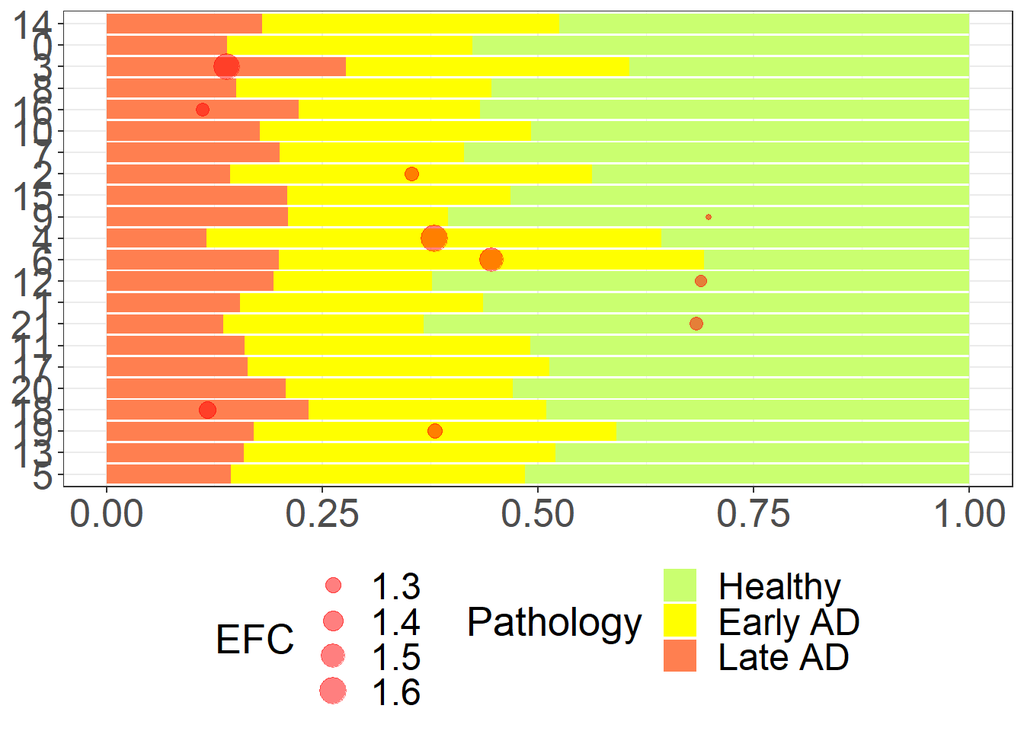

```r
probj
```